# Predição - Utilizando Ridge e Lasso

Nessa análise construíremos modelos preditivos de regressão para predição do CRA (Coeficiente de Rendimento Acadêmico) baseado nas notas obtidas nas disciplinas do primeiro e do segundo período dos alunos de Ciência da Computação - UFCG.

Bibliotecas utilizadas

```r
library(dplyr)
library(reshape2)
library(ggplot2)
library(corrplot)
library(caret)
library(leaps)
```

## Lendo os dados

Recebemos os dataset já separados em treino e test.

```r
graduados.train <- read.csv("dados/graduados_treino.csv")
graduados.validation <- read.csv("dados/graduados_teste.csv")
graduados.test <- read.csv("dados/test.csv")
```

## Conhecendo os dados

Um preprocessamento nos dados foi necessário, antes de iniciarmos nossa análise. Foi preciso calcular o CRA dos alunos e selecionar apenas as disciplinas referentes ao primeiro e segundo perído do curso. Após o processamento nossos dados ficaram no seguinte formato:

1. -

matricula

2. -

ano_evasao

3. -

periodo_evasao

4. -

cod_disciplina

5. -

disciplina

6. -

creditos

7. -

media

Após processarmos os dados tivemos que fazer mais algumas alterações para os dados ficassem no formato necessário para criar os modelos. Os atributos dos dados ficaram sendo as disciplinas e a última coluna como sendo a variável alvo. As linhas são as notas dos alunos, a matrícula foi removida devido a confidencialidade dos dados.

```r
head(train)
```

```
##                          matricula       C1 Vetorial      LPT       P1  IC
## 1 002b348d3bc88b68aa6ebd24cfc9d6a0 8.700000 8.000000 8.400000 5.600000 7.5
## 2 007961bf3929ae353c8585e6c09df369 7.600000 7.100000 7.700000 6.700000 8.5
## 3 00960ff73dd29b59f4432072c2219c04 8.500000 7.300000 7.500000 7.000000 5.6
## 4 00b6f55e3639c9d3b835751a39ca6309 7.766667 7.766667 7.766667 7.766667 7.3
## 5 00eb58fa89c562efda118e64efab77a5 6.300000 6.800000 8.600000 5.500000 7.0
## 6 01fc383ae2c2cb3e69d844272a5ecac0 8.800000 9.100000 9.500000 6.600000 5.9
##        LP1       C2 Discreta       P2   Grafos   Física      LP2      CRA
## 1 9.100000 8.109877 9.200000 7.700000 7.200000 9.600000 8.600000 8.109877
## 2 8.600000 6.975824 5.000000 5.700000 7.000000 7.800000 8.000000 6.975824
## 3 6.500000 6.057282 5.300000 5.600000 7.900000 7.000000 8.100000 6.057282
## 4 7.766667 7.200000 7.766667 7.766667 7.766667 7.766667 7.766667 7.766667
## 5 7.400000 7.693827 6.700000 7.900000 6.100000 7.100000 9.000000 7.693827
## 6 8.300000 6.722892 6.100000 6.800000 5.300000 7.300000 9.000000 6.722892
```

Antes de iniciarmos nossa análise vamos observar a correlação das variáveis em relação a variável alvo.

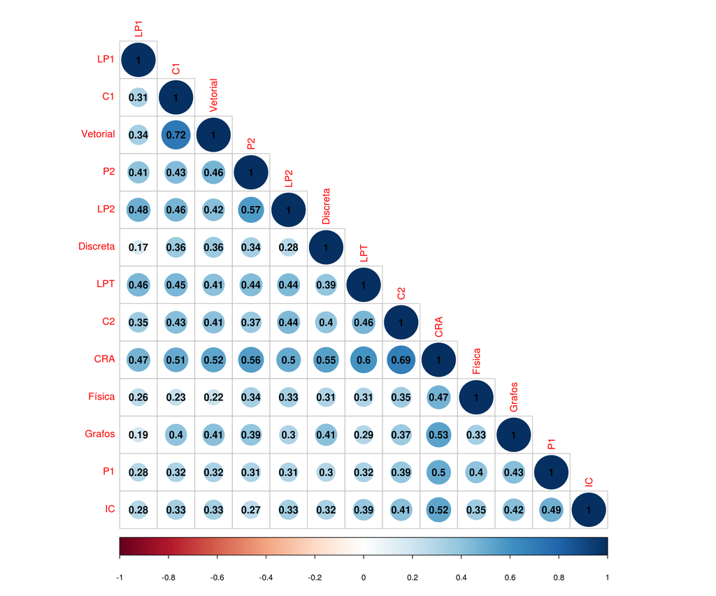

```r
#calculando matriz de correlação
correlationMatrix <- cor(train %>% select(-matricula))

#utlizamos a bibliota corrplot para montar o gráfico com as correlações
corrplot(correlationMatrix, method="circle", type="lower", order="hclust", addCoef.col = "black")
```

Vamos agora para nossa análise preditiva, para isso vamos seguir os passos descritos abaixo:

Usando todas as variáveis disponíveis (disciplinas do primeiro e segundo período), use validação cruzada (nos dados de treino) para tunar um modelo de regressão Ridge.

Mesmo que item acima mas usando um modelo de regressão Lasso.

Compare os dois modelos nos dados de teste em termos de RMSE.

Quais as variáveis mais importantes segundo o modelo de regressão Lasso? Alguma variável foi descartada? Quais?

Re-treine o melhor modelo (dessa vez nos dados de treino sem validação cruzada) e reporte o RMSE no teste.

Use o modelo treinado em 6 e aplique nos dados de teste que vamos disponibilizar.

Crie novos atributos a partir dos existentes para tentar melhorar o seu modelo.

## 2 Ridge

O modelo inicial utiliza o Ridge. A Ridge Regression é um método de regularização do modelo que tem como principal objetivo suavizar atributos que sejam relacionados uns aos outros e que aumentam o ruído no modelo (A.K.A multicolinearidade). Para aplicarmos o Ridge utilizamos a biblioteca caret.

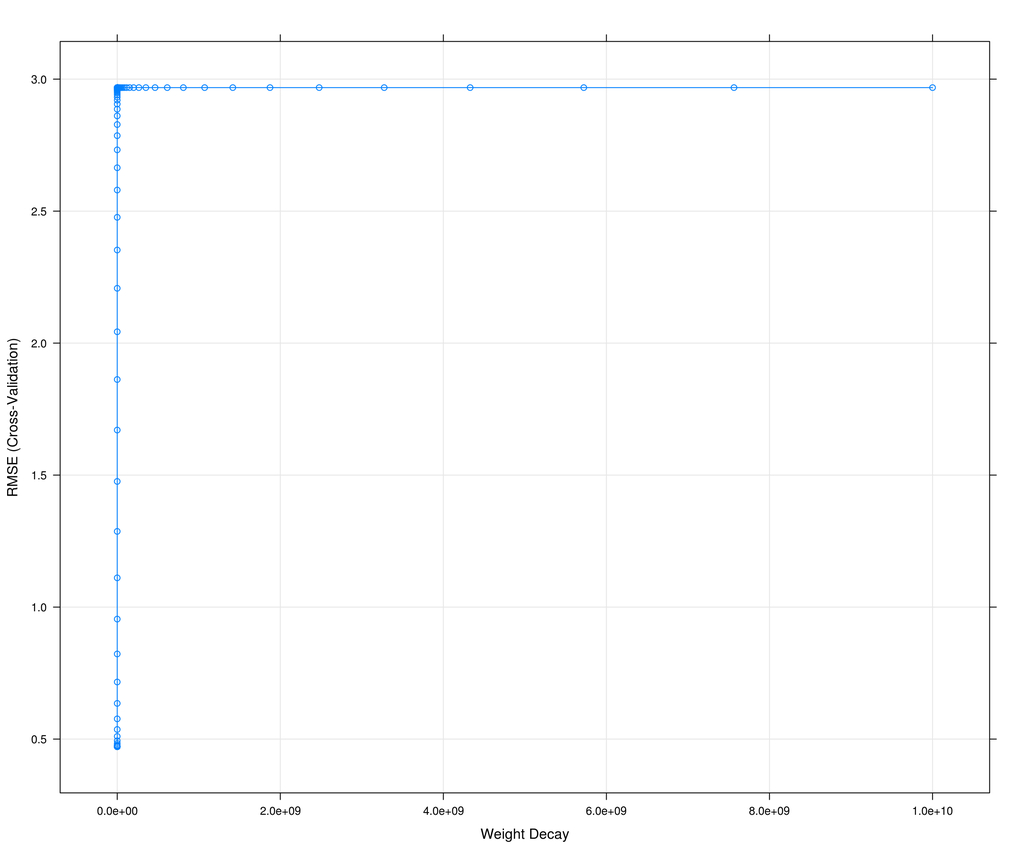

```r
#Modelo Ridge
set.seed(825)

ctrl <- trainControl(method = "cv", number = 10)
lambda.grid <- expand.grid(lambda = 10^seq(10, -2, length=100))

ridge <- train(CRA ~ . ,data = train %>% select(-matricula),
                        method = "ridge",
                        tuneGrid = lambda.grid,
                        trControl = ctrl,
                        metric = 'RMSE',
                        preProcess=c('scale', 'center'),
                        na.action = na.omit)
plot(ridge)
```

A função train utilizou um vetor com 100 possíveis valores para lambda e achou o valor ótimo (RMSE mais baixo).

```r
ridge
```

```
## Ridge Regression
##
## 511 samples
##  12 predictors
##
## Pre-processing: scaled (12), centered (12)
## Resampling: Cross-Validated (10 fold)
## Summary of sample sizes: 459, 460, 459, 460, 460, 462, ...
## Resampling results across tuning parameters:
##
##   lambda        RMSE       Rsquared
##   1.000000e-02  0.4711809  0.7117842
##   1.321941e-02  0.4711383  0.7118585
##   1.747528e-02  0.4710954  0.7119515
##   2.310130e-02  0.4710621  0.7120660
##   3.053856e-02  0.4710583  0.7122034
##   4.037017e-02  0.4711222  0.7123622
##   5.336699e-02  0.4713242  0.7125364
##   7.054802e-02  0.4717907  0.7127117
##   9.326033e-02  0.4727423  0.7128622
##   1.232847e-01  0.4745565  0.7129472
##   1.629751e-01  0.4778644  0.7129090
##   2.154435e-01  0.4836919  0.7126757
##   2.848036e-01  0.4936462  0.7121690
##   3.764936e-01  0.5101171  0.7113192
##   4.977024e-01  0.5364038  0.7100831
##   6.579332e-01  0.5766168  0.7084607
##   8.697490e-01  0.6352225  0.7065027
##   1.149757e+00  0.7162630  0.7043046
##   1.519911e+00  0.8224771  0.7019896
##   2.009233e+00  0.9545734  0.6996848
##   2.656088e+00  1.1107917  0.6975007
##   3.511192e+00  1.2868152  0.6955171
##   4.641589e+00  1.4760989  0.6937796
##   6.135907e+00  1.6706466  0.6923029
##   8.111308e+00  1.8621265  0.6910786
##   1.072267e+01  2.0430566  0.6900836
##   1.417474e+01  2.2077320  0.6892880
##   1.873817e+01  2.3526749  0.6886598
##   2.477076e+01  2.4765820  0.6881687
```

[output cut: 59 more lines]

```
##   4.641589e+08  2.9679512  0.6865490
##   6.135907e+08  2.9679512  0.6865490
##   8.111308e+08  2.9679512  0.6865490
##   1.072267e+09  2.9679512  0.6865490
##   1.417474e+09  2.9679512  0.6865490
##   1.873817e+09  2.9679512  0.6865490
##   2.477076e+09  2.9679512  0.6865490
##   3.274549e+09  2.9679512  0.6865490
##   4.328761e+09  2.9679512  0.6865490
##   5.722368e+09  2.9679512  0.6865490
##   7.564633e+09  2.9679512  0.6865490
##   1.000000e+10  2.9679512  0.6865490
##
## RMSE was used to select the optimal model using  the smallest value.
## The final value used for the model was lambda = 0.03053856.
```

Depois de criado o modelo iremos agora gerar a previsão.

```r
ridge_prediction <- predict(ridge, train)

ridge_prediction <- data.frame(pred = ridge_prediction, obs = train$CRA)
round(defaultSummary(ridge_prediction), digits = 3)
```

```
##     RMSE Rsquared
##    0.460    0.724
```

```r
ridge_prediction <- predict(ridge, validation)

ridge_prediction <- data.frame(pred = ridge_prediction, obs = validation$CRA)
round(defaultSummary(ridge_prediction), digits = 3)
```

```
##     RMSE Rsquared
##    0.451    0.669
```

## 3 Lasso

Iremos agora criar um modelo utilizando o Lasso. O Lasso é uma técnica que, além de controlar o overfitting, aplica a seleção de variáveis que melhor explicam a variável resposta. Para criar esse modelo usaremos a biblioteca caret.

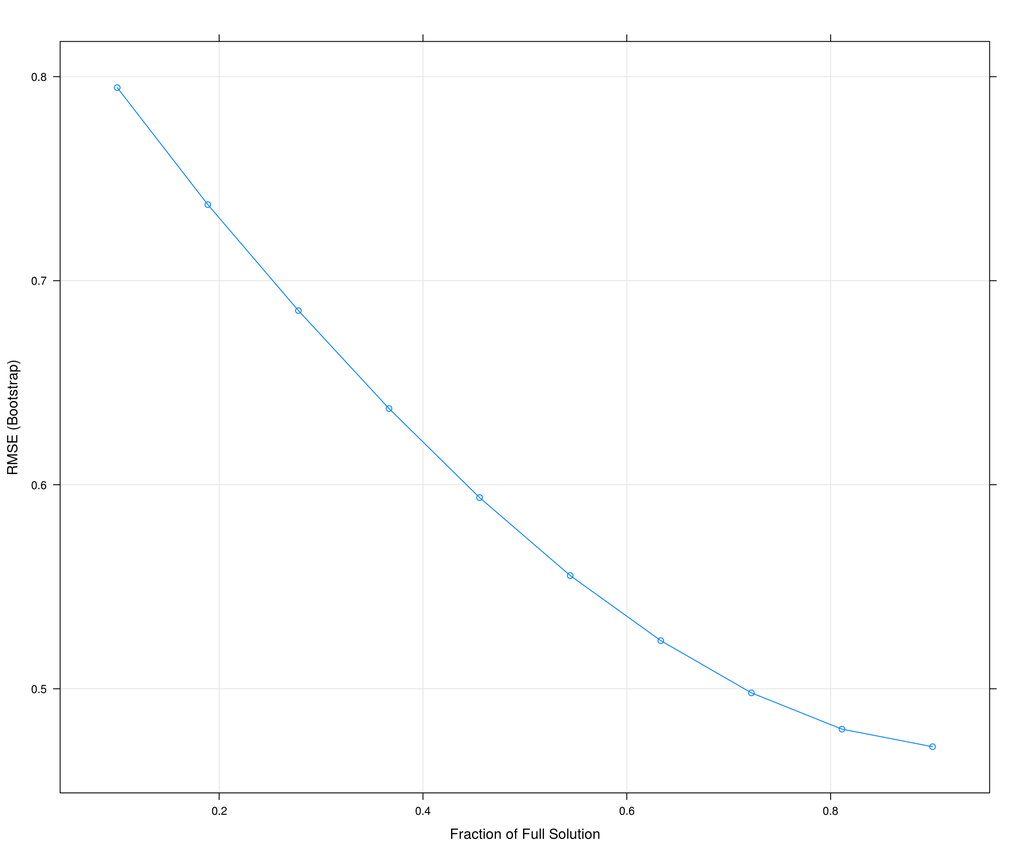

```r
#Modelo Lasso
set.seed(825)

lasso <- train(CRA ~ . ,data = train %>% select(-matricula),
                        method = "lasso",
                        tuneLength = 10,
                        metric = 'RMSE',
                        preProcess=c('scale', 'center'))
plot(lasso)
```

A função train tentou 10 valores para fraction e achou o valor ótimo (RMSE mais baixo).

```r
lasso
```

```
## The lasso
##
## 511 samples
##  12 predictors
##
## Pre-processing: scaled (12), centered (12)
## Resampling: Bootstrapped (25 reps)
## Summary of sample sizes: 511, 511, 511, 511, 511, 511, ...
## Resampling results across tuning parameters:
##
##   fraction   RMSE       Rsquared
##   0.1000000  0.7946249  0.4890410
##   0.1888889  0.7372794  0.5394617
##   0.2777778  0.6853431  0.5937181
##   0.3666667  0.6373354  0.6323418
##   0.4555556  0.5936996  0.6587734
##   0.5444444  0.5554971  0.6765716
##   0.6333333  0.5235953  0.6889876
##   0.7222222  0.4980050  0.6985056
##   0.8111111  0.4802144  0.7048619
##   0.9000000  0.4716005  0.7084270
##
## RMSE was used to select the optimal model using  the smallest value.
## The final value used for the model was fraction = 0.9.
```

Depois de criado o modelo iremos agora gerar a previsão.

```r
lasso_prediction <- predict(lasso, train)

lasso_prediction <- data.frame(pred = lasso_prediction, obs = train$CRA)
round(defaultSummary(lasso_prediction), digits = 3)
```

```
##     RMSE Rsquared
##    0.463    0.724
```

## 4 Comparando os modelos

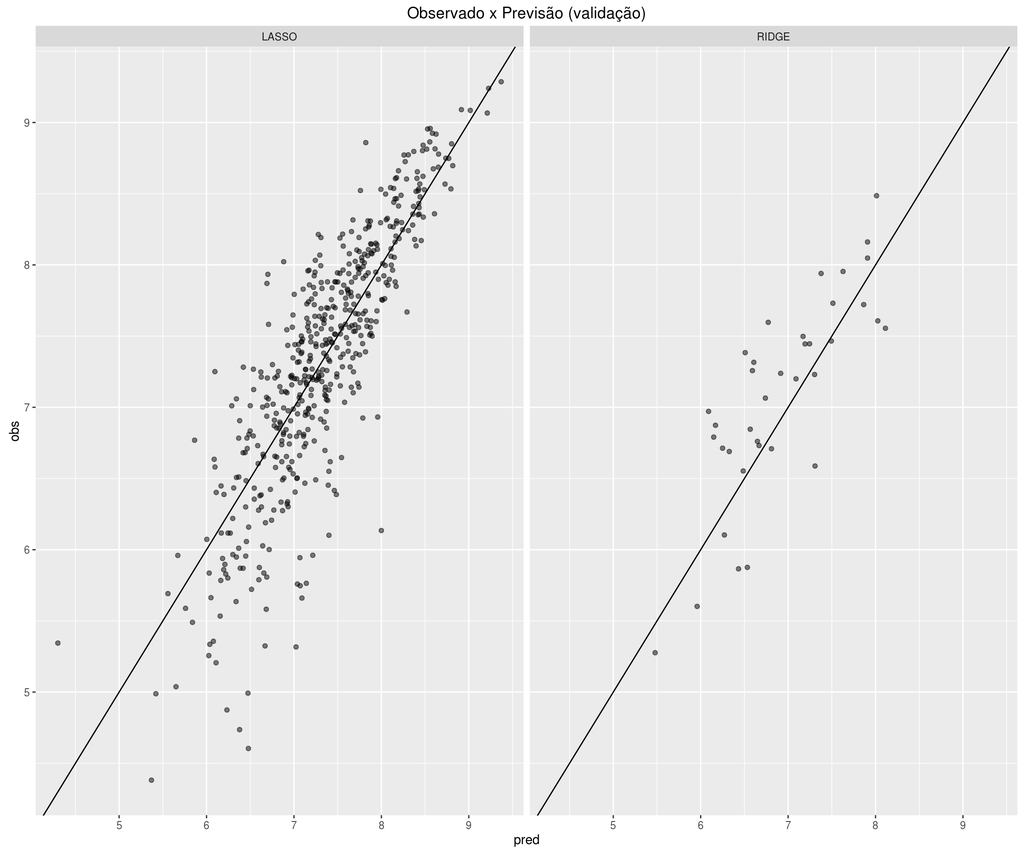

```r
compare <- ridge_prediction
compare$model <- "RIDGE"

lasso_prediction$model <- "LASSO"

compare <- rbind(compare, lasso_prediction)

ggplot(compare, aes(x = pred, y = obs)) +
  geom_point(alpha = 0.5, position = position_jitter(width=0.2)) +
  facet_grid(. ~ model) +
  geom_abline() +
  ggtitle("Observado x Previsão (validação)")
```

```r
round(defaultSummary(ridge_prediction), digits = 3)
```

```
##     RMSE Rsquared
##    0.451    0.669
```

```r
round(defaultSummary(lasso_prediction), digits = 3)
```

```
##     RMSE Rsquared
##    0.463    0.724
```

## 5 Importância das Variáveis

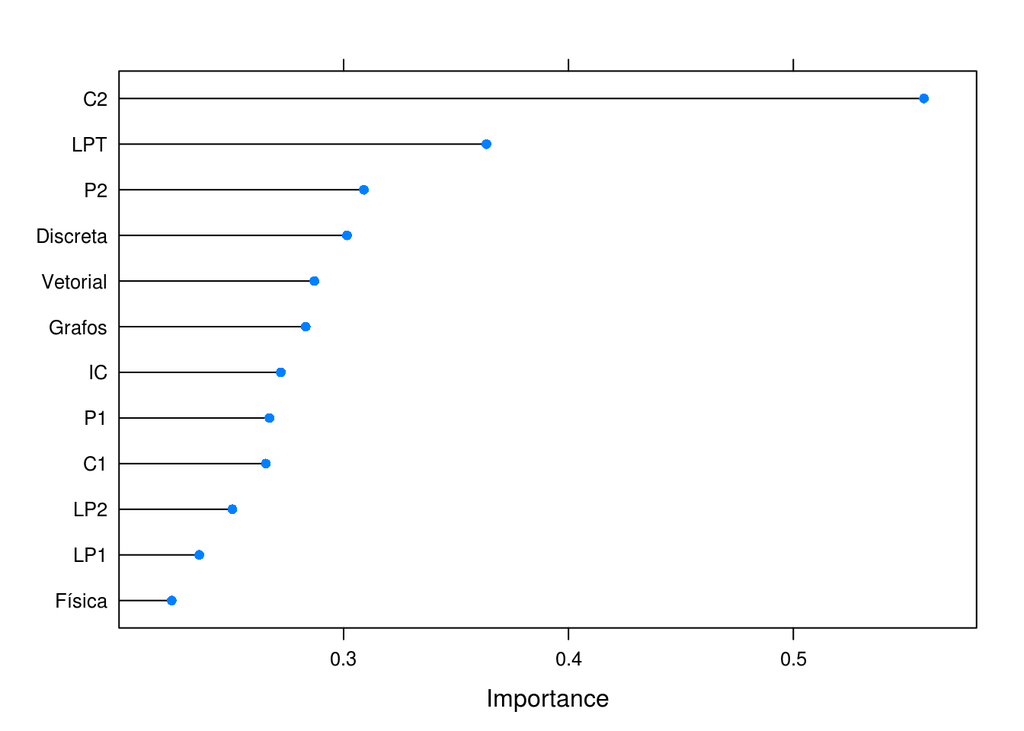

```r
plot(varImp(ridge, scale = FALSE))
```

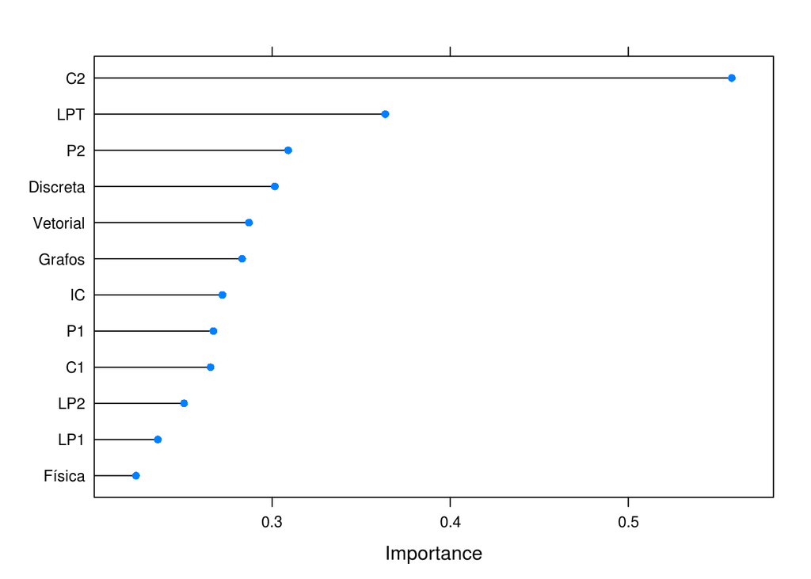

```r
plot(varImp(lasso, scale = FALSE))
```

```r
predict.enet(lasso$finalModel, type='coefficients', s=lasso$bestTune$fraction, mode='fraction')
```

```
## $s
## [1] 0.9
##
## $fraction
##   0
## 0.9
##
## $mode
## [1] "fraction"
##
## $coefficients
##         C1   Vetorial        LPT         P1         IC        LP1
## 0.00000000 0.04672828 0.12795243 0.05328715 0.06711077 0.07376776
##         C2   Discreta         P2     Grafos     Física        LP2
## 0.26600334 0.12534072 0.10915876 0.09690094 0.06370152 0.00000000
```

Acima temos o gráfico com a importância das variáveis para cada modelo, primeiro para o ridge depois para o lasso. Concluímos que as variáveis possuem a mesma importância para cada modelo. No lasso foi removida algumas variáveis, como mostrado acima, as variáveis C1 e LP2 foram removidas.

A variável C2 se mostrou muito improtante para ambos os modelos, vamos observar mais a fundo esse relacionamento no plot abaixo.

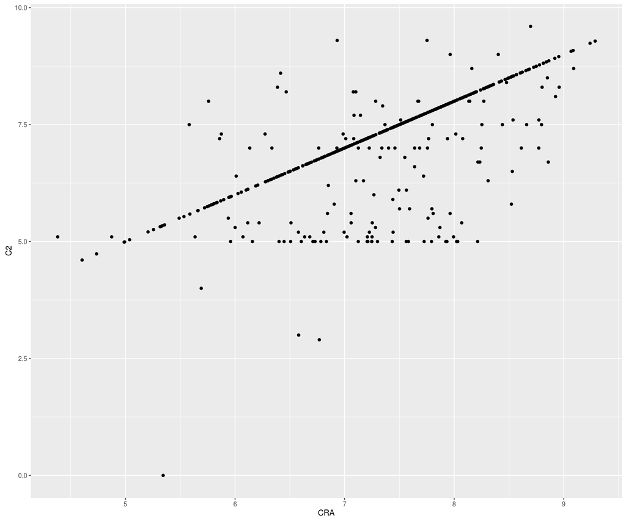

```r
ggplot(data = train, aes(x = CRA, y = C2)) +
  geom_point()
```

Vemos que C2 e CRA tem um comportamento bem linear, temos alguns outliers, mas podemos concluir que quanto mais alta a nota em C2 consequentemente mais alto o CRA.

```r
r.ridge <- train(CRA ~ . ,data = train %>% select(-matricula),
                        method = "ridge",
                        metric = 'RMSE',
                        preProcess=c('scale', 'center'))
r.ridge
```

```
## Ridge Regression
##
## 511 samples
##  12 predictors
##
## Pre-processing: scaled (12), centered (12)
## Resampling: Bootstrapped (25 reps)
## Summary of sample sizes: 511, 511, 511, 511, 511, 511, ...
## Resampling results across tuning parameters:
##
##   lambda  RMSE       Rsquared
##   0e+00   0.4746285  0.7090461
##   1e-04   0.4746251  0.7090509
##   1e-01   0.4753823  0.7119443
##
## RMSE was used to select the optimal model using  the smallest value.
## The final value used for the model was lambda = 1e-04.
```

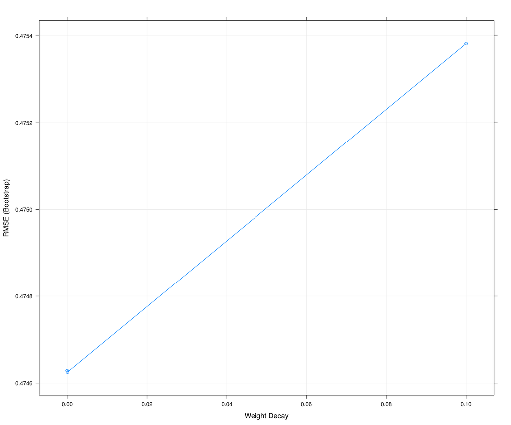

```r
plot(r.ridge)
```

```r
#predicao do re-treino
r_ridge_prediction <- predict(r.ridge, train)

r_ridge_prediction <- data.frame(pred = r_ridge_prediction, obs = train$CRA)
round(defaultSummary(r_ridge_prediction), digits = 3)
```

```
##     RMSE Rsquared
##    0.459    0.724
```

## 7 Treino com dados de teste

```r
ridge_prediction_validation <- predict(ridge, validation)

#validacao
ridge_prediction_validation <- data.frame(pred = ridge_prediction_validation, obs = validation$CRA)
round(defaultSummary(ridge_prediction_validation), digits = 3)
```

```
##     RMSE Rsquared
##    0.451    0.669
```

```r
#sumissao pro kaggle
#submissao <- data.frame(matricula = graduados.test$matricula,
#                     cra = lasso_prediction_t)
#write.csv(submissao, file = "sub5.csv", row.names = F)
```

Mesmo após o retreino do modelo com os dados de validação, o RMSE se mantém quase o mesmo, a variação é muito insignificante.

## 8 Comparando Modelos com treino e teste

Para termos uma comparação mais robusta, propusemos um modelo de regressão linear. Primeiro rodamos com todas as variáveis, depois só com as mais significativas e tivemos o seguinte resultado.

```r
lm <- train(CRA ~ . ,train %>% select(-matricula), method= "lm", metric="RMSE")
summary(lm)
```

```
##
## Call:
## lm(formula = .outcome ~ ., data = dat)
##
## Residuals:
##      Min       1Q   Median       3Q      Max
## -1.99684 -0.24220  0.02893  0.30180  1.31251
##
## Coefficients:
##             Estimate Std. Error t value Pr(>|t|)
## (Intercept)  0.23299    0.22540   1.034 0.301783
## C1           0.00270    0.02574   0.105 0.916505
## Vetorial     0.04261    0.02447   1.741 0.082233 .
## LPT          0.13248    0.02710   4.888 1.37e-06 ***
## P1           0.04809    0.02047   2.349 0.019233 *
## IC           0.05796    0.01987   2.917 0.003699 **
## LP1          0.09057    0.02490   3.638 0.000304 ***
## C2           0.23522    0.02284  10.298  < 2e-16 ***
## Discreta     0.11360    0.02053   5.532 5.11e-08 ***
## P2           0.10371    0.02389   4.342 1.71e-05 ***
## Grafos       0.08534    0.02128   4.010 7.02e-05 ***
## Física       0.06573    0.02073   3.171 0.001614 **
## LP2         -0.01654    0.02879  -0.574 0.565954
## ---
## Signif. codes:  0 '***' 0.001 '**' 0.01 '*' 0.05 '.' 0.1 ' ' 1
##
## Residual standard error: 0.4654 on 498 degrees of freedom
## Multiple R-squared:  0.7243, Adjusted R-squared:  0.7176
## F-statistic:   109 on 12 and 498 DF,  p-value: < 2.2e-16
```

```r
lmFit <- train(CRA ~ ., train %>% select(-matricula, -C1, -LP2), method= "lm", metric="RMSE")
summary(lmFit)
```

```
##
## Call:
## lm(formula = .outcome ~ ., data = dat)
##
## Residuals:
##      Min       1Q   Median       3Q      Max
## -2.00060 -0.23888  0.03121  0.30053  1.29574
##
## Coefficients:
##             Estimate Std. Error t value Pr(>|t|)
## (Intercept)  0.19812    0.21542   0.920 0.358159
## Vetorial     0.04289    0.02007   2.137 0.033052 *
## LPT          0.13184    0.02672   4.935 1.09e-06 ***
## P1           0.04818    0.02044   2.358 0.018775 *
## IC           0.05724    0.01980   2.891 0.004005 **
## LP1          0.08726    0.02418   3.608 0.000339 ***
## C2           0.23342    0.02247  10.387  < 2e-16 ***
## Discreta     0.11395    0.02049   5.562 4.34e-08 ***
## P2           0.09921    0.02248   4.414 1.24e-05 ***
## Grafos       0.08573    0.02118   4.048 5.99e-05 ***
## Física       0.06478    0.02063   3.140 0.001788 **
## ---
## Signif. codes:  0 '***' 0.001 '**' 0.01 '*' 0.05 '.' 0.1 ' ' 1
##
## Residual standard error: 0.4646 on 500 degrees of freedom
## Multiple R-squared:  0.7241, Adjusted R-squared:  0.7185
## F-statistic: 131.2 on 10 and 500 DF,  p-value: < 2.2e-16
```

```r
lmFit_prediction <- predict(lmFit, train)

lmFit_prediction <- data.frame(pred = lmFit_prediction, obs = train$CRA)
round(defaultSummary(lmFit_prediction), digits = 3)
```

```
##     RMSE Rsquared
##    0.460    0.724
```

Nosso modelo linear apresentou um RMSE parecido com o dos modelos já expostos, porém com um alto R-squared. No gráfico abaixo podemos analisar nossa comparação.

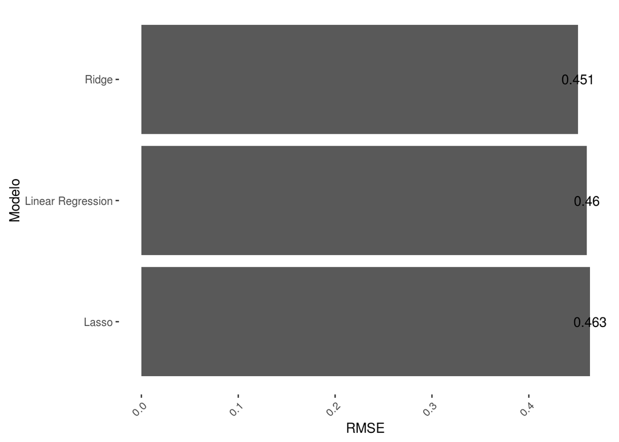

```r
linear_rmse <- round(defaultSummary(lmFit_prediction), digits = 3)[1]
ridge_rmse <- round(defaultSummary(ridge_prediction), digits = 3)[1]
lasso_rmse <- round(defaultSummary(lasso_prediction), digits = 3)[1]
toPlot <- data.frame(RMSE = c(linear_rmse, ridge_rmse, lasso_rmse),
                     Modelo = c("Linear Regression", "Ridge", "Lasso"))


ggplot(toPlot, aes(x=reorder(Modelo, -RMSE), y=RMSE)) +
  geom_bar(stat="identity") +
  labs(x='Modelo', y='RMSE') +
   theme(axis.text.x = element_text(angle = 45, hjust = 1), panel.background=element_blank()) +
  coord_flip() +
  geom_text(aes(label = RMSE))
```

O melhor modelo será aquele que possuir o RMSE mais baixo. Utilizando essa métrica o melhor modelo gerado foi o utilizando Ridge com o cross validation seguido pelo modelo utilizando regressão linear e depois o Lasso. Vale salientar que a diferença entre os modelos é baixissíma.

### Treino vs Validação

```r
ridge_prediction_v <- predict(ridge, validation)
ridge_prediction_v <- data.frame(pred = ridge_prediction_v, obs = validation$CRA)

lasso_prediction_v <- predict(lasso, validation)
lasso_prediction_v <- data.frame(pred = lasso_prediction_v, obs = validation$CRA)

lm_prediction_v <- predict(lm, validation)
lm_prediction_v <- data.frame(pred = lm_prediction_v, obs = validation$CRA)


linear_rmse_v <- round(defaultSummary(lm_prediction_v), digits = 3)[1]
ridge_rmse_v <- round(defaultSummary(ridge_prediction_v), digits = 3)[1]
lasso_rmse_v <- round(defaultSummary(lasso_prediction_v), digits = 3)[1]
```

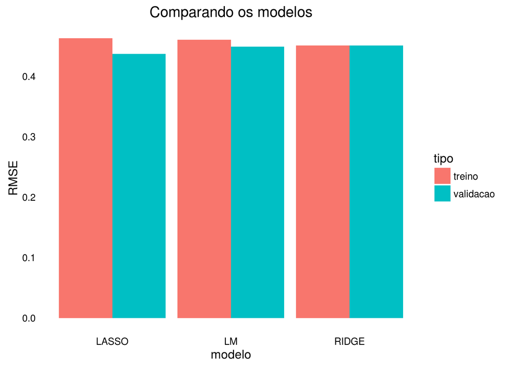

```r
toPlot3 <- data.frame(RMSE = c(linear_rmse, linear_rmse_v, ridge_rmse, ridge_rmse_v, lasso_rmse, lasso_rmse_v),
                        tipo = c("treino", "validacao", "treino", "validacao", "treino", "validacao"),
                        modelo = c("LM","LM","RIDGE", "RIDGE","LASSO", "LASSO"))

ggplot(data=toPlot3, aes(x = modelo, y = RMSE, fill = tipo, label=RMSE)) +
 geom_bar(stat="identity", position=position_dodge()) +
 theme_classic() +
 labs(title = "Comparando os modelos") +
 theme(axis.ticks = element_blank())
```

No gráfico acima temos uma comparação entre os modelos propostos, analisando o RMSE com os dados de treino e validação.

## 9 Melhorando o modelo

Com o intuito de melhorar nosso modelo, ou seja, tentar diminuir o RMSE vamos adicionar novas colunas aos nossos dados com novos atributos.

```r
#novas features
add_new_features <- function(new_df){
  new_df$mediaProg <- ((new_df$P1+new_df$LP1) + (new_df$P2+new_df$LP2))/2

  new_df$mediaDSC <- (new_df$P1 + new_df$LP1 + new_df$IC + new_df$Grafos + new_df$Discreta)/5

  new_df$mediaDME <- (new_df$C1+new_df$C2+new_df$Vetorial)/2

  new_df$C2squared <- new_df$C2^2

  new_df$logP2 <- log(new_df$P2)

  new_df$logMediaProg <- log(new_df$mediaProg)

  return(new_df)
}

new_train <- add_new_features(train)
new_validation <- add_new_features(validation)
```

Foram adicionadas 6 novas colunas:

mediaProg

média das disciplinas de programação

mediaDSC

média das disciplinas ofertadas pelo departamento de computação

mediaDME

média das disciplinas ofertadas pelo departamento de matemática

C2squared

nota de cálculo 2 ao quadrado

logP2

log da nota de P2

Utilizamos a mediaProg para termos a média das disciplinas exclusivas de programação, o mesmo foi pensado para as disciplinas do DSC e do DME, a nota de C2 se mostrou muito importante, por isso elevamos esse valor ao quadrado. Aplicamos o log nas notas de P2 e mediaProg devido a elas terem apresentado uma alta importância. Após esse incremento nos dados vamos rodar o modelo e ver como ele se comporta.

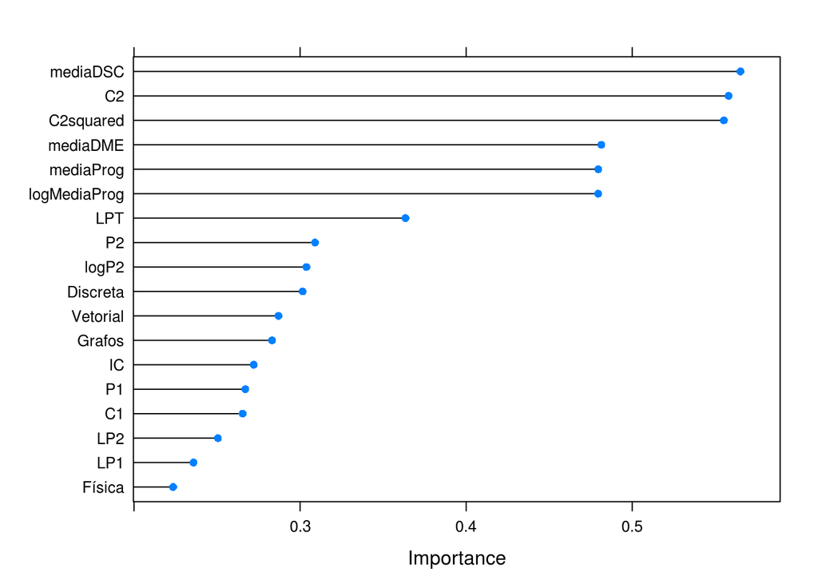

```r
set.seed(825)
best.lasso <- train(CRA ~ . ,data = new_train %>% select(-matricula),
                        method = "lasso",
                        tuneLength = 10,
                        metric = 'RMSE',
                        preProcess=c('scale', 'center'))

plot(varImp(best.lasso, scale = FALSE))
```

```r
predict.enet(best.lasso$finalModel, type='coefficients', s=lasso$bestTune$fraction, mode='fraction')
```

```
## $s
## [1] 0.9
##
## $fraction
##   0
## 0.9
##
## $mode
## [1] "fraction"
##
## $coefficients
##           C1     Vetorial          LPT           P1           IC
##  0.006522594  0.044854717  0.120356108 -0.054327437  0.070533048
##          LP1           C2     Discreta           P2       Grafos
##  0.000000000 -0.361320430  0.126300399 -0.014652004  0.105772573
##       Física          LP2    mediaProg     mediaDSC     mediaDME
##  0.072032212 -0.118743401 -0.544785681  0.000000000  0.000000000
##    C2squared        logP2 logMediaProg
##  0.659176731  0.024175688  0.853722706
```

```r
best.lasso_prediction_train <- predict(best.lasso, new_train)
best.lasso_prediction_validation <- predict(best.lasso, new_validation)


#treino
best.lasso_prediction_train <- data.frame(pred = best.lasso_prediction_train, obs = new_train$CRA)
round(defaultSummary(best.lasso_prediction_train), digits = 3)
```

```
##     RMSE Rsquared
##    0.450    0.736
```

```r
#validacao
best.lasso_prediction_validation <- data.frame(pred = best.lasso_prediction_validation, obs = new_validation$CRA)
round(defaultSummary(best.lasso_prediction_validation), digits = 3)
```

```
##     RMSE Rsquared
##    0.456    0.658
```